# Docker and Containers

## Що таке Docker?

**Docker** Це платформа для розробки, доставки та запуску додатків у контейнерах.

[figure not shown]

## Що таке контейнер?

Контейнер - це окрема віртуальна машина, яка містить все необхідне для запуску програми: код, бібліотеки, залежності та налаштування. Вона знаходитться на машині користувача, має окрему операційну систему, але використовує ресурси хост-машини (процесор, пам’ять, диск).

**Особливості контейнера**

- Власна ОС
- Власні бібліотеки
- Власні залежності
- Власні налаштування
- легко переноситься

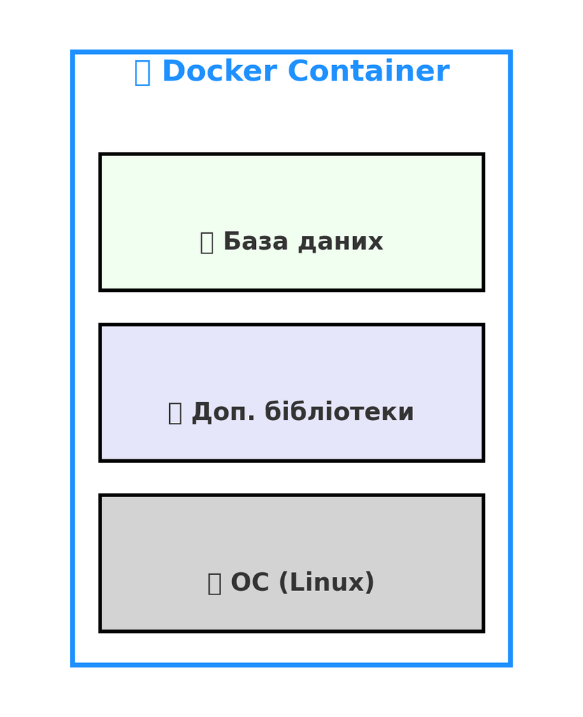

# Контейнер == “міні” віртуальна машина (такий як Windows, Linux, MacOS)

# Чому це корисно?

**Головна проблема комунікації розробників це:**

- “На моєму комп’ютері працює, сподіваюся, що у тебе теж”
- “В мене не запускається, бо в мене інша версія Python”
- “В мене не запускається бо маю Mac”

# Рішення

Якщо всі будуть мати однакове середовище, то проблем не буде.

**Питання:** як це зробити?

# Рішення 1

Встановлювати всі залежності вручну і контролювати версії пакетів, бібліотек один одного.

**- Складно**

**- Різні ОС**

**- Різні версії**

**- Важко підтримувати**

# Рішення 2

Використовувати пакети, що спрощують встановлення залежностей, наприклад, `requirements.txt` для Python або `renv` для R.

- Важко встановити
- Важко підтримувати
- Багато пакетів для різних мов
- Охоплює не всі залежності
- Встановлюю більшість залежностей
- Працює на своїй ОС

# Рішення 3

Використовувати контейнери, наприклад, `Docker`.

- Потребує місце на диску
- Потребує ресурси (CPU, RAM)
- Потрібно вивчити базові команди
- Встановлює всі залежності
- Працює на власній ОС, тому байду яка ОС у користувача
- Легко переноситься
- Повне налаштування середовища

# Як працює Docker?

[figure not shown]

## Dockerfile - інструкції для створення image (образу)

Dockerfile - це будь-який текстовий файл, який читає Docker для створення образу (image). Він містить усі інструкції, по типу:

- Яка ОС
- Які залежності
- Які файли входять до контейнера

*DOCKERFILE - це рецепт створення образу (image)*

## Docker Image - це шаблон (шаблонна віртуальна машина)

Docker Image - це шаблон (шаблонна віртуальна машина), який створюється на основі інструкцій з Dockerfile. В цьому документу є інструкції по будуванні контейнера, але вже у форматі команд, що не розуміє людина, а розуміє Docker.

*IMAGE - це шаблон віртуальної машини або інструкція для створення контейнера*

## Docker Container - це запущений образ (image)

Docker Container - це запущений образ (image). Це вже повноцінна віртуальна машина, яка працює на вашому комп’ютері. Вона має власну ОС, бібліотеки, залежності та налаштування.

*CONTAINER - це запущений образ (image) або віртуальна, що готова до роботи*

## Що потрібно для початку?

- Встановити Docker Desktop з [офіційного сайту](https://www.docker.com/products/docker-desktop)
- Зареєструватися на [Docker Hub](https://hub.docker.com) для зберігання своїх образів (image) або їх завантаження
- Завантажити будь-який образ (image) з Docker Hub або створити свій власний за допомогою Dockerfile

## Базові команди Docker

```bash
docker pull <image_name>      # Завантажити образ (image) з Docker Hub
```

```bash
docker images                 # Показати всі завантажені образи
```

```bash
docker run -it <image_name>   # Запустити контейнер з образом (image)
```

```bash
docker ps                     # Показати всі запущені контейнери
```

```bash
docker build -t <image_name> .   # Створити власний образ (image) з Dockerfile що знаходиться в поточній папці
```

## Варто пам’ятати що Docker це один з інструментів для роботи з контейнерами, є й інші, наприклад:

- Podman
- Kubernetes
- OpenShift
- AWS ECS